# Tarea realizada por Carlos Sánchez Polo y Jesús Martínez Leal

Última edición: 29/02/2024

**Table of contents**

- PCA vs Kernel PCA
  - Carga de librerías y de dataset
  - Definición de funciones para graficar y preguntas iniciales
    - ¿Qué representa el valor de gamma en un kernel RBF y cuál sería el valor de gamma óptimo?
    - Cambia el tipo de kernel y analiza los resultados. ¿Qué kernel funciona mejor?
  - Análisis con el dataset de Moons
    - Kernel RBF con distintos valores de $\gamma$
    - Otras combinaciones de Kernel
  - Análisis con el dataset de Circlecs
    - Kernel RBF con distintos valores de $\gamma$
    - Otras combinaciones de Kernel

# PCA vs Kernel PCA

`PCA` resulta adecuado para datos lineales y proporciona interpretaciones más directas de las componentes principales. KPCA es más flexible y potente para manejar estructuras no lineales en los datos, aunque puede requerir una mayor atención en la selección y ajuste del kernel.

Esto se verá en los sucesivos gráficos.

## Carga de librerías y de dataset

```python
#NumPy: numerical scientific computing
import numpy as np

#Scikit-learn: machine learning
from sklearn import datasets
from sklearn.decomposition import PCA, KernelPCA

#Matplotlib: plotting
import matplotlib.pyplot as plt
%matplotlib inline
#%matplotlib notebook
```

```python
#Generacion datos
#np.random.seed(0)
X_moons, y_moons = datasets.make_moons(n_samples=500, random_state = 77) #10 100 500
```

## Definición de funciones para graficar y preguntas iniciales

```python
def Params_KPCA(X=X_moons, y = y_moons, kernel="rbf", gamma=15, degree=3, inverse=True, filename_prefix="KPCA", plot=True, save=False):
    try:
        # Transformaciones PCA y KPCA
        X_pca = PCA().fit_transform(X)

        kpca = KernelPCA(kernel=kernel, gamma=gamma, degree=degree, fit_inverse_transform=inverse).fit(X)

        X_kpca = kpca.transform(X)
        X_back = kpca.inverse_transform(X_kpca)

        # Representacion datos transformados
        reds = y == 0
        blues = y == 1

        if plot:
            plt.figure(figsize=(8, 6))  # Ajusta el tamaño de la figura según sea necesario

            if kernel == 'poly':
                suptitle = f'Kernel: {kernel}, Gamma: {gamma}, Degree: {degree}'
            elif kernel in ['rbf', 'sigmoid']:
                suptitle = f'Kernel: {kernel}, Gamma: {gamma}'
            else:
                suptitle = f'Kernel: {kernel}, Degree: {degree}'

            plt.suptitle(suptitle, y=1.02)  # Ajusta la posición vertical del título principal

            plt.subplot(2, 2, 1, aspect='equal')
            plt.plot(X[reds, 0], X[reds, 1], "ro")
            plt.plot(X[blues, 0], X[blues, 1], "bo")
            plt.title("Original space")
            plt.xlabel("$x_1$")
            plt.ylabel("$x_2$")

            plt.subplot(2, 2, 2, aspect='equal')
            plt.plot(X_pca[reds, 0], X_pca[reds, 1], "ro")
            plt.plot(X_pca[blues, 0], X_pca[blues, 1], "bo")
            plt.title("Projection by PCA")
            plt.xlabel("1st principal component")
            plt.ylabel("2nd component")

            plt.subplot(2, 2, 3, aspect='equal')
            plt.plot(X_kpca[reds, 0], X_kpca[reds, 1], "ro")
            plt.plot(X_kpca[blues, 0], X_kpca[blues, 1], "bo")
            plt.title("Projection by KPCA")
            plt.xlabel("1st principal component in space induced by $\phi$")
            plt.ylabel("2nd component")

            plt.subplot(2, 2, 4, aspect='equal')
            plt.plot(X_back[reds, 0], X_back[reds, 1], "ro")
            plt.plot(X_back[blues, 0], X_back[blues, 1], "bo")
            plt.title("Original space after inverse transform")
            plt.xlabel("$x_1$")
            plt.ylabel("$x_2$")

            plt.tight_layout()  # Ajusta automáticamente la disposición de los subplots para evitar superposiciones

            if save:
                # Guardar la figura con un nombre acorde a los parámetros
                filename = f"./data/{filename_prefix}_kernel-{kernel}_gamma-{gamma}_degree-{degree}.png"
                plt.savefig(filename)

            plt.show()
        else:
            return None
    except Exception as e:
        print(f"Error al generar la figura para kernel={kernel}, gamma={gamma}, degree={degree}: {e}")
        return None
```

### ¿Qué representa el valor de gamma en un kernel RBF y cuál sería el valor de gamma óptimo?

El valor de $\gamma$ en un kernel RBF (Radial Basis Function) representa la influencia de cada ejemplo de entrenamiento en la función de kernel.

Un valor más alto de $\gamma$ significa que cada ejemplo tiene un alcance más local en el cálculo del kernel (valor de $\sigma$ más pequeño), lo que puede llevar a un ajuste más preciso pero también a un mayor riesgo de sobreajuste.

Un valor más bajo de $\gamma$ implica lo contrario, tendremos una influencia más amplia de los ejemplos de entrenamiento, lo que puede llevar a un modelo más generalizado pero posiblemente menos preciso.

La relación entre $\gamma$ y $\sigma$ viene dada por:

$$ \gamma = \frac{1}{2 \sigma^2} $$

### Cambia el tipo de kernel y analiza los resultados. ¿Qué kernel funciona mejor?

Encontramos los distintos tipos de Kernel disponibles en la función `KernelPCA()` en el enlace: https://scikit-learn.org/stable/modules/generated/sklearn.decomposition.KernelPCA.html.

Los distintos Kernel posibles son:

- Linear
- Poly
- RBF
- Sigmoid
- Cosine
- Precomputed

Vemos además, según la documentación, que el parámetro de `degree` es solo utilizado para el kernel de tipo Poly.

El parámetro $\gamma$ es el propio en RBF, Poly y Sigmoid. Se ignora para otros Kernels. Si se establece en `None`, entonces se establece en $1/n_{features}$

El kernel "sigmoid" genera un error.

Se define una función que permite graficar múltiples plots variando los parámetros de KPCA

```python
def plot_KPCA_variations(X, y, kernels = ['rbf'], degrees = [3], gammas = [3]):
    for kernel in kernels:
        for degree in degrees:
            for gamma in gammas:
                Params_KPCA(X=X, y = y, kernel=kernel, degree=degree, gamma=gamma)
```

## Análisis con el dataset de Moons

### Kernel RBF con distintos valores de $\gamma$

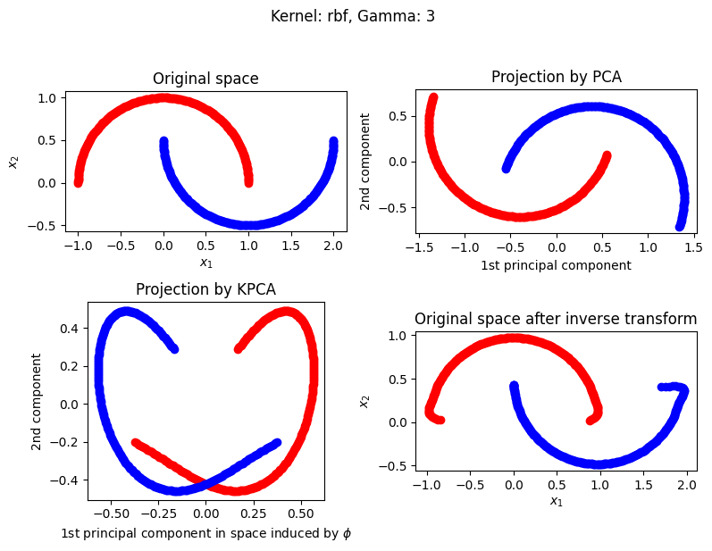

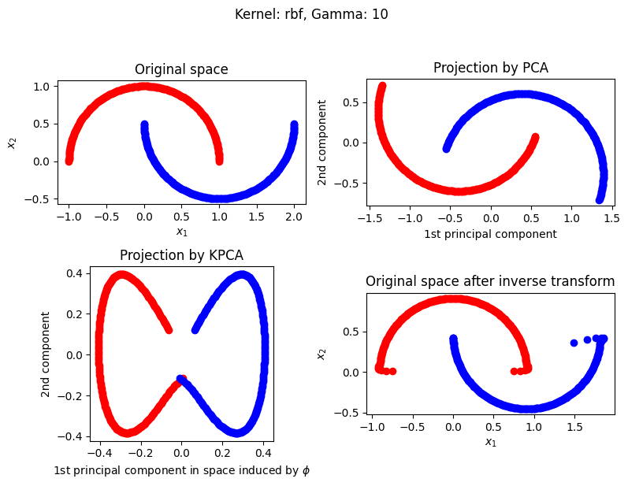

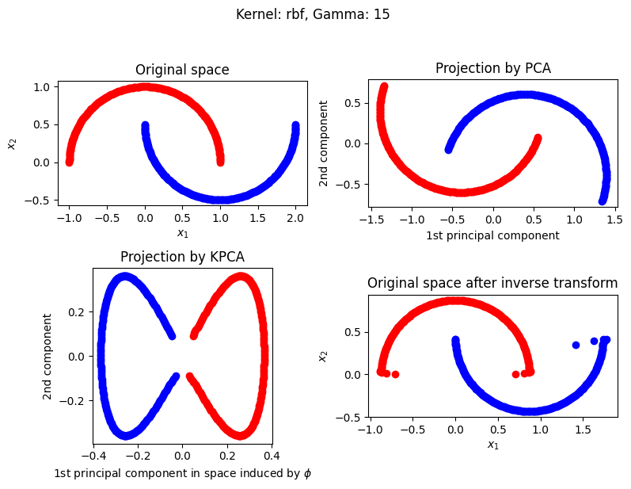

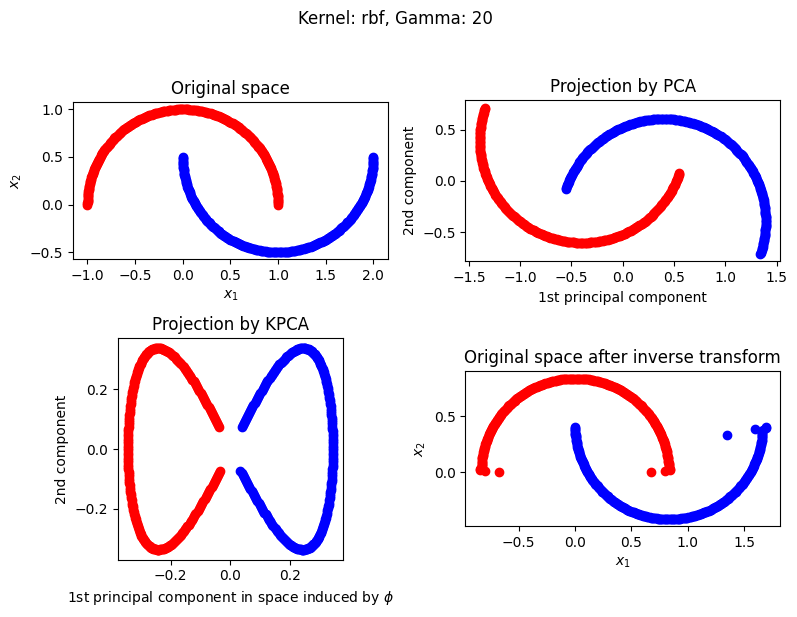

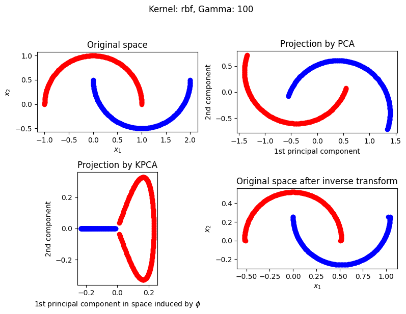

```python
plot_KPCA_variations(X = X_moons, y = y_moons, kernels = ['rbf'], gammas = [3, 10, 15, 20, 100])
```

Utilizando el kernel `rbf` obtenemos una separación óptima de las clases para un gamma entorno al 15, aunque parece que valores mas altos tambien funcionan. El parámetro `gamma` hace referencia a la anchura del kernel gaussiano, por lo que necesitamos que nuestro kernel sea lo suficientemente pequeño como para asociar solamente los puntos de la misma clase pero lo suficientemente grande como para encontrar similitudes entre los puntos de la misma clase dada la separación del dataset.

### Otras combinaciones de Kernel

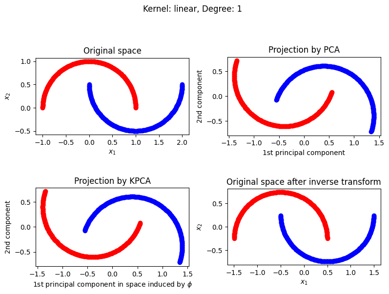

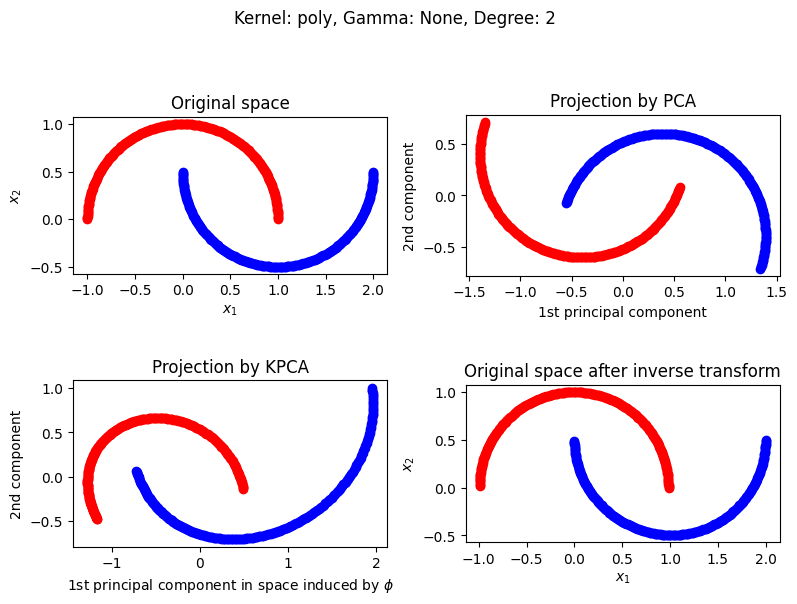

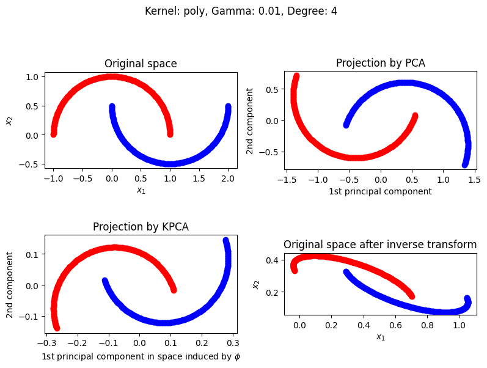

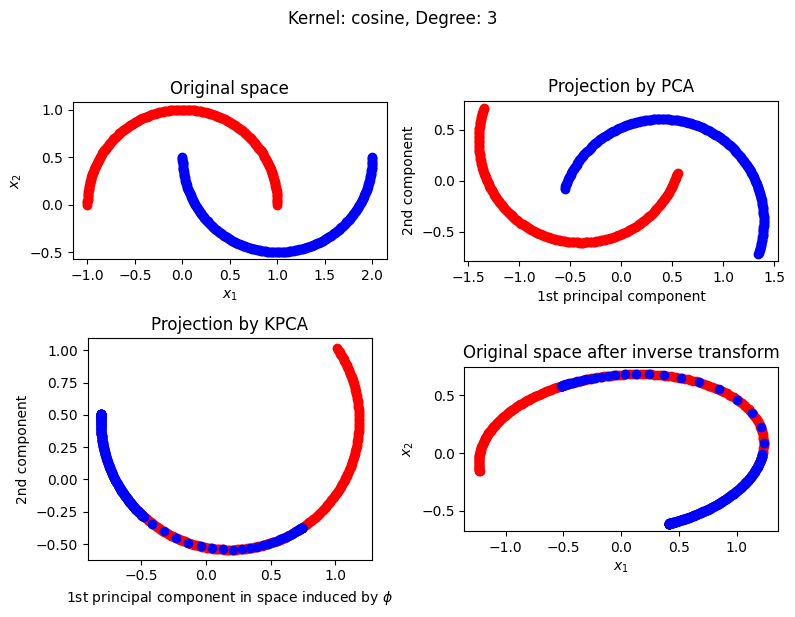

```python
Params_KPCA(X = X_moons, y = y_moons, kernel = "linear", gamma = None, degree = 1)
Params_KPCA(X = X_moons, y = y_moons, kernel = "poly", gamma = None, degree = 2)
Params_KPCA(X = X_moons, y = y_moons, kernel = "poly", gamma = 0.01, degree = 4)
Params_KPCA(X = X_moons, y = y_moons, kernel = "cosine", gamma = None)
```

Observamos como el Kernel `linear` es equivalente a la PCA, no introduciéndose una modelización no lineal.

Con el Kernel polinómico `poly` tampoco pudo obtenerse de manera satisfactoria una separación lineal en ese nuevo espacio, mientras que el de coseno, `cosine`, obtiene resultados bastante pésimos.

## Análisis con el dataset de Circlecs

### Kernel RBF con distintos valores de $\gamma$

```python
X_circ, y_circ = datasets.make_circles(n_samples=500, random_state=77, noise=0.05, factor=0.2)
```

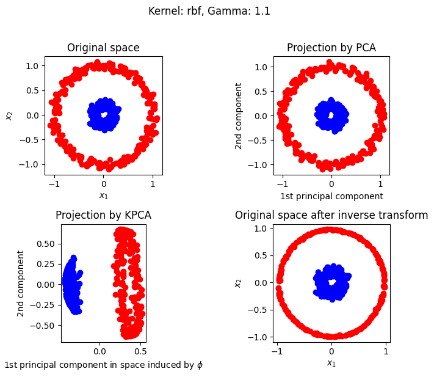

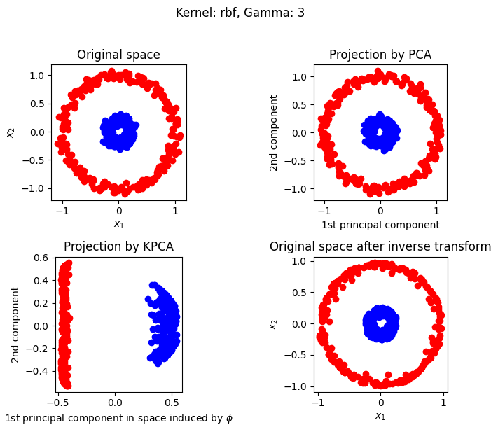

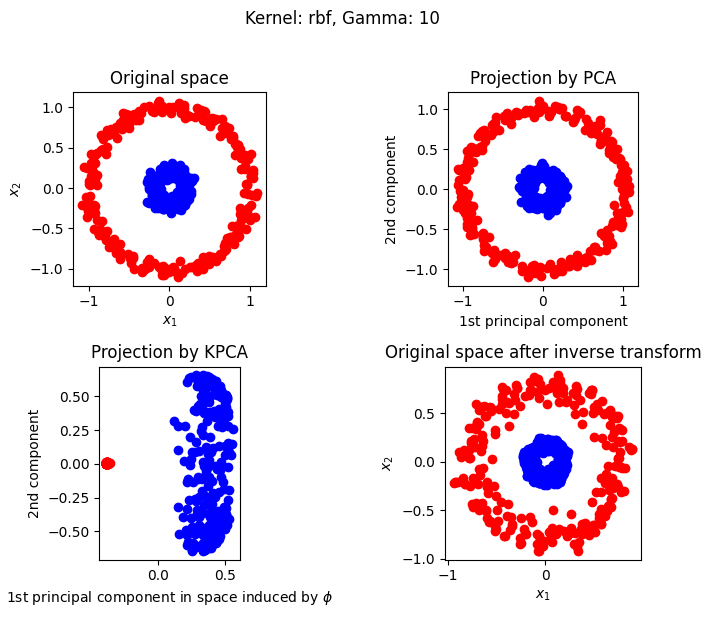

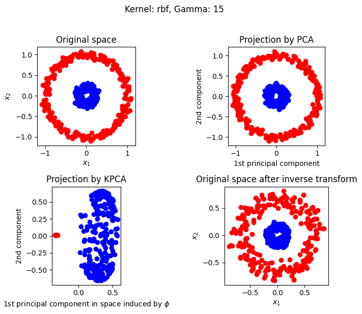

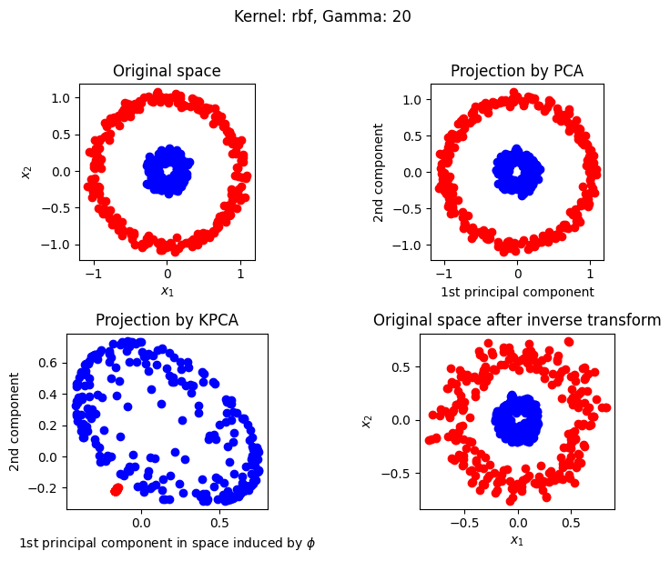

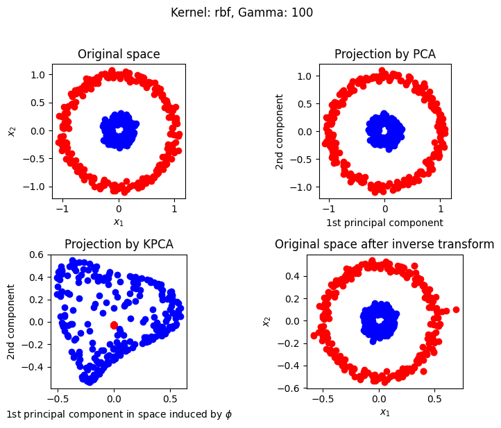

```python
plot_KPCA_variations(X = X_circ, y = y_circ, kernels = ['rbf'], gammas = [1.1, 3, 10, 15, 20, 100])
```

### Otras combinaciones de Kernel

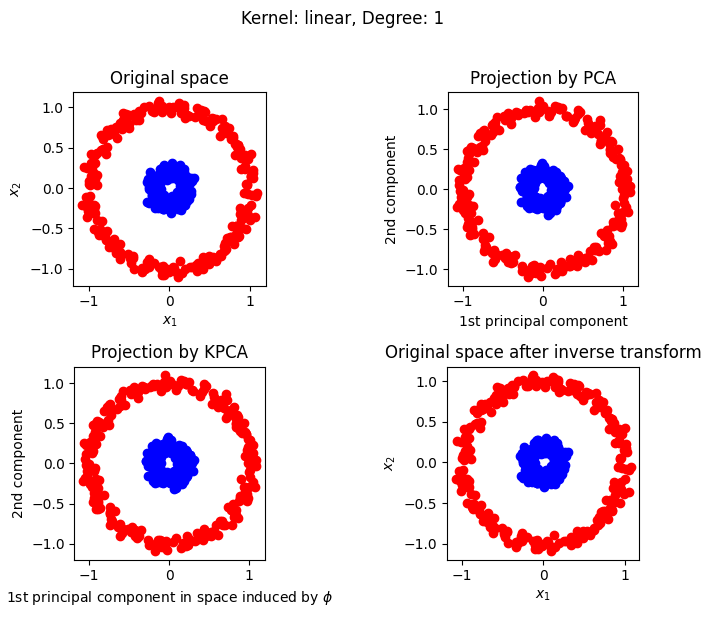

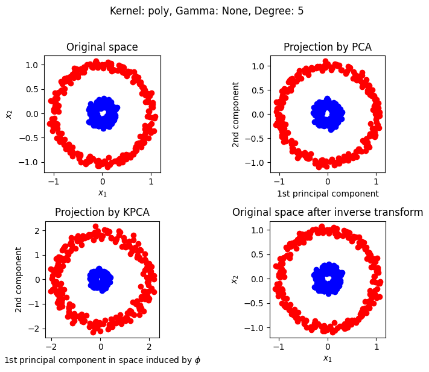

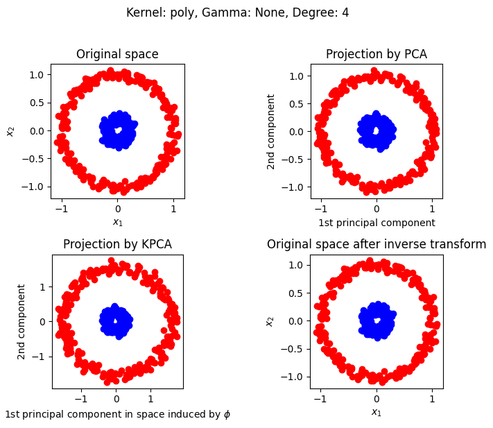

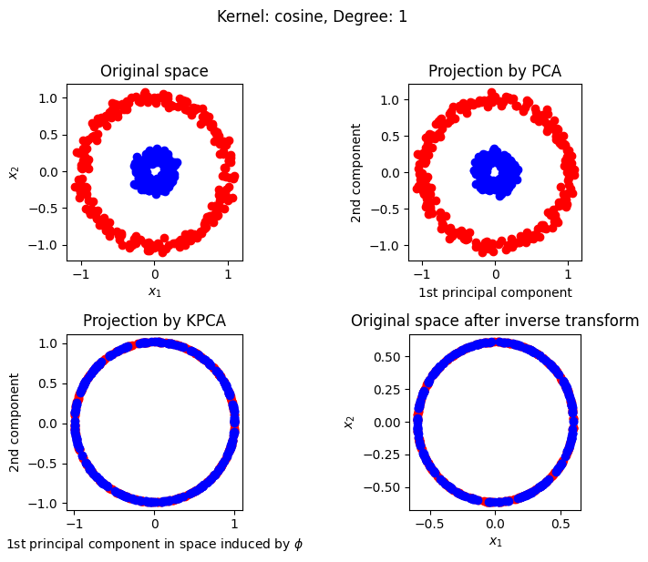

```python
Params_KPCA(X = X_circ, y = y_circ, kernel = "linear", gamma = None, degree = 1)
Params_KPCA(X = X_circ, y = y_circ, kernel = "poly", gamma = None, degree = 5)
Params_KPCA(X = X_circ, y = y_circ, kernel = "poly", gamma = None, degree = 4)
Params_KPCA(X = X_circ, y = y_circ, kernel = "cosine", degree = 1)
```

Vemos un desastre total a la hora de poder separar linealmente nuestros datos con un hiperplano en ese nuevo espacio.